# C(art)ography

Exploring digital cartography as a creative outlet and to gain experience with relevant software.

## Blender Shaded Relief Maps

Inspired by folks like [Daniel Huffman](https://somethingaboutmaps.wordpress.com/) and [Scott Reinhard](https://scottreinhard.com/) who are bringing old topo maps to life using digital elevation models.

Rather than creating a hillshade in a GIS program, Blender can be used to create more aesthetically pleasing hillshades. I use ArcGIS Pro for data gathering & reprojection, Blender to create a 3d model of the terrain and simulate a hillshade, and Adobe Photoshop for combining the hillshade with the old topo maps. Still a lot to learn and improve upon, but I enjoy learning new programs and this was a good excuse to get my feet wet in Blender.

### Island of Kauai

Hillshade made in Blender:

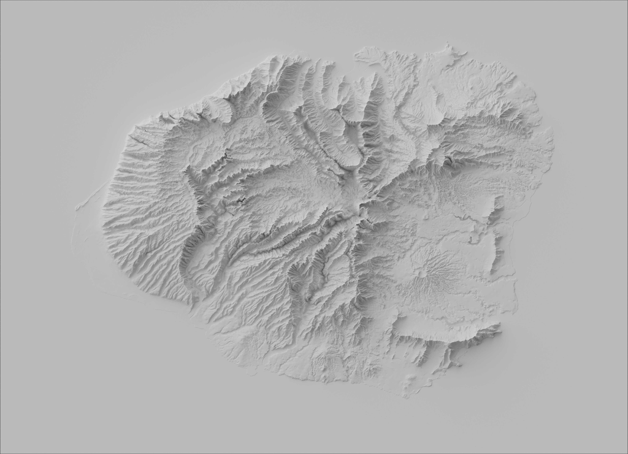

Final:

[figure not shown]

Compare to original image from [Ball State University Digital Media library](https://dmr.bsu.edu/digital/collection/USTpMp/id/25):

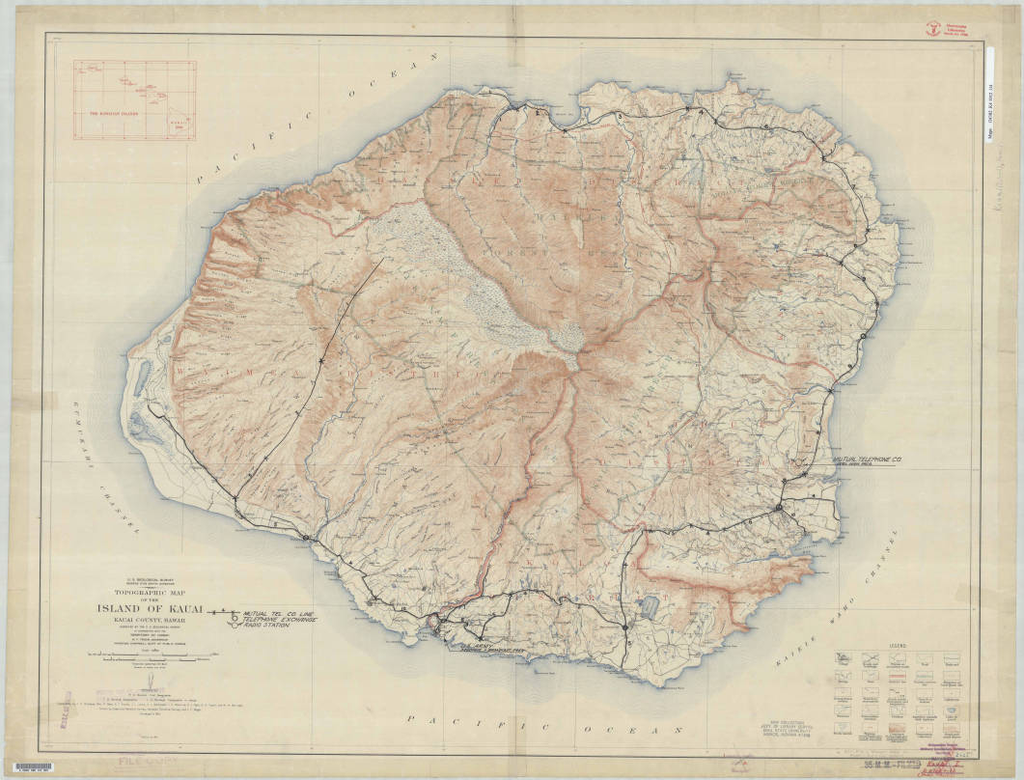

### Bryn Mawr, PA

An older shaded relief I made for my sister who goes to school in the area.

[figure not shown]

Turns out it’s a rather flat chunk of the Earth. Topo map from [USGS historical topo collection](https://www.usgs.gov/programs/national-geospatial-program/historical-topographic-maps-preserving-past).

## Bay Area Land Cover Map Poster

Made in the style of a WPA poster. ArcGIS Pro and Photoshop. Inspired by [John Nelson](https://www.esri.com/arcgis-blog/author/j_nelson/).

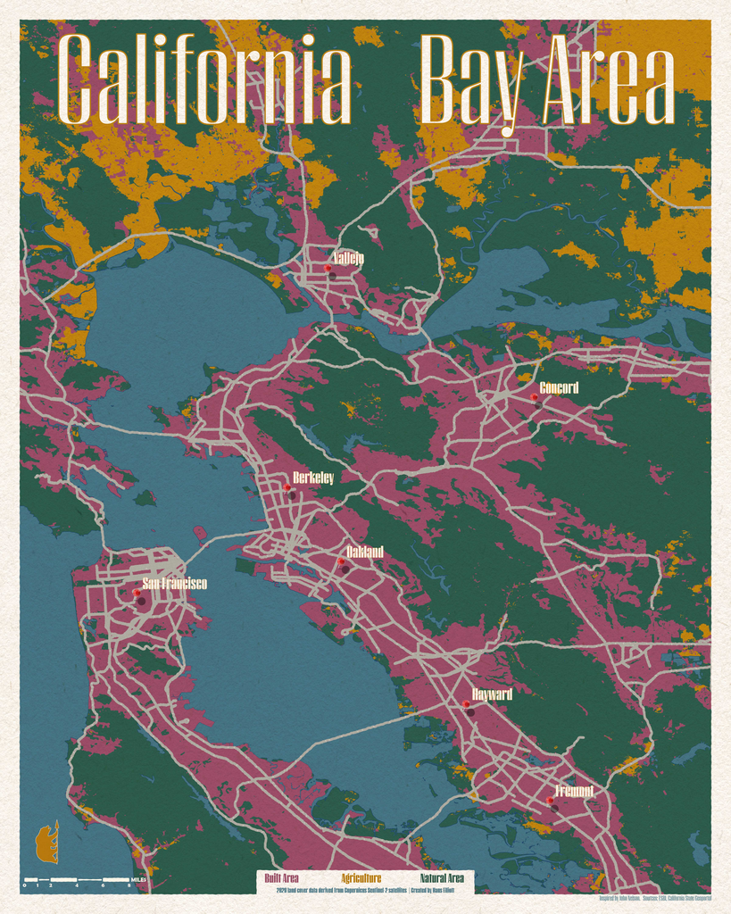

[Hans Elliott](https://hans-elliott99.github.io/)

*hanselliott61@gmail.com*